# Tomato Model

We describe a model for tomato yellow curl leaf virus disease and using @Holt1999 data we implement the model in Stan. The model used is bases on a SLI-SI model and it is fitted to each tomato specie data.

Thus, the model is described by the following formulation:

$$\begin{align}
S_p'& =
-\beta_p S_p I_v + r_1 L_p + r_2 I_p
\\
L_p'& =
\beta_p S_p I_v -(b + r_1) L_p
\\
I_p'& =
b L_p - r_2 I_p
\\
S_v'&=
-\beta_v S_v I_p - (\gamma + \gamma_f) S_v + (1 - \theta) \mu
\\
I_v'&=
\beta_v S_v I_p - (\gamma + \gamma_f) I_v +\theta \mu
\\
N_p(t)&=
S_p + L_p + I_p
\\
N_v(t)&=
S_v + I_v
\end{align}$$

with $S_p(t)$, $L_p(t)$ and $I_p(t)$ represents the number of susceptibles, latented and infected plants at time t (in days) in the crop. $N_p(t)$ is the total population size $(N_p=S_p + L_p + I_p)$. $\beta_p$ is the rate of transmission of susceptible plants by infected vectors, $r_1$, $r_2$ are replanting rates of latent and infected plants, respectively, $b$ latency rate, plant latent becomes infectious. $\beta_v$ is the infection rate of susceptible vectors by an infected plant. $\gamma$, $\gamma_f$ are vector death and fumigation rate. $\mu$ is the vector migration rates from alternative plants to crop and $\theta$ is the proportion vector migration rate.

# Observation Model

The unique solution of ODE model is defined when we give the parameters and initial conditions, this solution include the number of new infected plants, $\lambda_t$. We want to link the solution of ODE model with the observed data, the number of infected cases, $I_{obs}(t)$, at each time point. We decide to model the number of infected plants with a count distribution – the Negative Binomial. This distribution admits us to use the incidence $\lambda_t$ as the expected value and account for over-dispersion, through the parameter $\phi$:
$$\begin{align}
Y_t &
\sim \text{Negative Binomial}(\lambda_t, \phi), \qquad
\\
\lambda_t &
= \int_0^t b L_p(s)ds
\\
& \beta_p \sim \text{Normal(0.01,0.001)}
\\
& r_1 \sim \text{Inv-Gamma(2.005,0.01005)}
\\
& r_2 \sim \text{Inv-Gamma(2.005,0.01005)}
\\
& b \sim \text{Inv-Gamma(70.625,0.496875)}
\\
& \beta_v \sim \text{Normal(0.001,0.001)}
\\
& \theta \sim \text{Normal(0.4, 0.1)}
\\
& \phi \sim \text{Exponential(1.9)}
\end{align}$$

# Stan ODE notation beginning model

[output not shown]

# Parameters estimation

[output not shown]

# Stan estimation LA 1582 specie data

```r
library(knitr)
library(kableExtra)
#
sub_path_1 <- "/home/gabrielsalcedo"
sub_path_2 <- "Documentos/TYLCVD-fit"
sub_path_3 <- "Model5/estimation/LA_data"
file_name <- "last_est.csv"
path <- paste(sub_path_1, sub_path_2, sub_path_3, file_name, sep = "/")
parameters_df <- read.csv(path, header=FALSE,skip = 1)
parameters_df <- data.frame(parameters_df)
#
colnames(parameters_df) <- c("theta",
                        "mean",
                        'se_mean',
                        'sd',
                        '2.5%', '25%','50%', '75%' ,'97.5%',
                        'n_eff',
                        'Rhat')
kable(parameters_df)  %>%
  kable_styling(bootstrap_options = "striped", full_width = T)
```

| theta | mean | se_mean | sd | 2.5% | 25% | 50% | 75% | 97.5% | n_eff | Rhat |
| --- | --- | --- | --- | --- | --- | --- | --- | --- | --- | --- |
| theta[1] | 9.593200e-02 | 0.0000373 | 0.0036554 | 8.654440e-02 | 9.419060e-02 | 9.696040e-02 | 9.869070e-02 | 9.988480e-02 | 9596.895384 | 1.0000348 |
| theta[2] | 5.241700e-03 | 0.0000360 | 0.0036017 | 1.586700e-03 | 2.943000e-03 | 4.287400e-03 | 6.370000e-03 | 1.479800e-02 | 9996.529104 | 1.0000570 |
| theta[3] | 6.798800e-03 | 0.0000507 | 0.0049351 | 1.766000e-03 | 3.398800e-03 | 5.254900e-03 | 8.530600e-03 | 2.120800e-02 | 9491.902197 | 0.9998758 |
| theta[4] | 7.277572e-01 | 0.0012671 | 0.1275266 | 4.988198e-01 | 6.319834e-01 | 7.223455e-01 | 8.216464e-01 | 9.739224e-01 | 10129.457568 | 0.9997368 |
| theta[5] | 5.814100e-03 | 0.0000259 | 0.0026014 | 9.354000e-04 | 3.945900e-03 | 5.740300e-03 | 7.543800e-03 | 1.121910e-02 | 10071.298391 | 0.9998496 |
| theta[6] | 1.500000e-01 | 0.0000000 | 0.0000000 | 1.500000e-01 | 1.500000e-01 | 1.500000e-01 | 1.500000e-01 | 1.500000e-01 | 2.501876 | 0.9994999 |
| theta[7] | 1.500000e-01 | 0.0000000 | 0.0000000 | 1.500000e-01 | 1.500000e-01 | 1.500000e-01 | 1.500000e-01 | 1.500000e-01 | 2.501876 | 0.9994999 |
| theta[8] | 3.996553e-01 | 0.0005280 | 0.0535942 | 3.033306e-01 | 3.624283e-01 | 3.960723e-01 | 4.341435e-01 | 5.124754e-01 | 10301.433074 | 0.9997705 |
| theta[9] | 1.000000e+00 | NA | 0.0000000 | 1.000000e+00 | 1.000000e+00 | 1.000000e+00 | 1.000000e+00 | 1.000000e+00 | NA | NA |
| theta[10] | 5.114395e+01 | 0.0120241 | 1.1852222 | 5.002792e+01 | 5.033008e+01 | 5.076715e+01 | 5.156848e+01 | 5.435685e+01 | 9716.126276 | 0.9999753 |
| R_0 | 4.118918e-01 | 0.0034645 | 0.3407474 | 3.987100e-02 | 1.714642e-01 | 3.173282e-01 | 5.532578e-01 | 1.323535e+00 | 9673.234291 | 0.9998493 |
| y_init[1] | 9.340000e+02 | NA | 0.0000000 | 9.340000e+02 | 9.340000e+02 | 9.340000e+02 | 9.340000e+02 | 9.340000e+02 | NA | NA |
| y_init[2] | 6.500000e+01 | NA | 0.0000000 | 6.500000e+01 | 6.500000e+01 | 6.500000e+01 | 6.500000e+01 | 6.500000e+01 | NA | NA |
| y_init[3] | 1.000000e+00 | NA | 0.0000000 | 1.000000e+00 | 1.000000e+00 | 1.000000e+00 | 1.000000e+00 | 1.000000e+00 | NA | NA |
| y_init[4] | 3.014395e+04 | 12.0241171 | 1185.2221852 | 2.902792e+04 | 2.933008e+04 | 2.976715e+04 | 3.056848e+04 | 3.335685e+04 | 9716.126276 | 0.9999753 |
| y_init[5] | 1.000000e+03 | NA | 0.0000000 | 1.000000e+03 | 1.000000e+03 | 1.000000e+03 | 1.000000e+03 | 1.000000e+03 | NA | NA |
| y_init[6] | 2.000000e+04 | NA | 0.0000000 | 2.000000e+04 | 2.000000e+04 | 2.000000e+04 | 2.000000e+04 | 2.000000e+04 | NA | NA |
| y_init[7] | 1.000000e+00 | NA | 0.0000000 | 1.000000e+00 | 1.000000e+00 | 1.000000e+00 | 1.000000e+00 | 1.000000e+00 | NA | NA |

# Stan estimation tyking specie data

```r
library(knitr)
library(kableExtra)
#
sub_path_1 <- "/home/gabrielsalcedo"
sub_path_2 <- "Documentos/TYLCVD-fit"
sub_path_3 <- "Model5/estimation/tyking_data"
file_name <- "last_est.csv"
path <- paste(sub_path_1, sub_path_2, sub_path_3, file_name, sep = "/")
parameters_df <- read.csv(path, header=FALSE,skip = 1)
parameters_df <- data.frame(parameters_df)
#
colnames(parameters_df) <- c("theta",
                        "mean",
                        'se_mean',
                        'sd',
                        '2.5%', '25%','50%', '75%' ,'97.5%',
                        'n_eff',
                        'Rhat')
kable(parameters_df)  %>%
  kable_styling(bootstrap_options = "striped", full_width = T)
```

| theta | mean | se_mean | sd | 2.5% | 25% | 50% | 75% | 97.5% | n_eff | Rhat |
| --- | --- | --- | --- | --- | --- | --- | --- | --- | --- | --- |
| theta[1] | 0.0077196 | 0.0000034 | 0.0006726 | 0.0064401 | 0.0072561 | 0.0077078 | 0.0081688 | 0.0090742 | 40033.7879 | 0.9999638 |
| theta[2] | 0.0004987 | 0.0000005 | 0.0001003 | 0.0003011 | 0.0004308 | 0.0004985 | 0.0005664 | 0.0006948 | 40927.3143 | 0.9999293 |
| theta[3] | 0.0004865 | 0.0000005 | 0.0001000 | 0.0002899 | 0.0004189 | 0.0004869 | 0.0005542 | 0.0006825 | 40322.9222 | 0.9999403 |
| theta[4] | 0.5183549 | 0.0010083 | 0.2011367 | 0.1997699 | 0.3584912 | 0.4952684 | 0.6607415 | 0.9378877 | 39792.4736 | 0.9999981 |
| theta[5] | 0.0002606 | 0.0000006 | 0.0001211 | 0.0001063 | 0.0001640 | 0.0002363 | 0.0003311 | 0.0005506 | 40045.7615 | 1.0000422 |
| theta[6] | 0.1500000 | 0.0000000 | 0.0000000 | 0.1500000 | 0.1500000 | 0.1500000 | 0.1500000 | 0.1500000 | 2.0003 | 0.9999000 |
| theta[7] | 0.1500000 | 0.0000000 | 0.0000000 | 0.1500000 | 0.1500000 | 0.1500000 | 0.1500000 | 0.1500000 | 2.0003 | 0.9999000 |
| theta[8] | 0.4000000 | 0.0000000 | 0.0000000 | 0.4000000 | 0.4000000 | 0.4000000 | 0.4000000 | 0.4000000 | 2.0003 | 0.9999000 |
| theta[9] | 1.0000000 | NA | 0.0000000 | 1.0000000 | 1.0000000 | 1.0000000 | 1.0000000 | 1.0000000 | NA | NA |
| R_0 | 0.0144423 | 0.0000392 | 0.0078653 | 0.0049925 | 0.0086445 | 0.0126398 | 0.0182909 | 0.0341456 | 40303.1536 | 0.9999566 |
| y_init[1] | 999.8000000 | 0.0000000 | 0.0000000 | 999.8000000 | 999.8000000 | 999.8000000 | 999.8000000 | 999.8000000 | 2.0003 | 0.9999000 |
| y_init[2] | 0.1000000 | 0.0000000 | 0.0000000 | 0.1000000 | 0.1000000 | 0.1000000 | 0.1000000 | 0.1000000 | 2.0003 | 0.9999000 |
| y_init[3] | 0.1000000 | 0.0000000 | 0.0000000 | 0.1000000 | 0.1000000 | 0.1000000 | 0.1000000 | 0.1000000 | 2.0003 | 0.9999000 |
| y_init[4] | 15.0000000 | NA | 0.0000000 | 15.0000000 | 15.0000000 | 15.0000000 | 15.0000000 | 15.0000000 | NA | NA |
| y_init[5] | 0.0000000 | NA | 0.0000000 | 0.0000000 | 0.0000000 | 0.0000000 | 0.0000000 | 0.0000000 | NA | NA |
| y_init[6] | 985.0000000 | NA | 0.0000000 | 985.0000000 | 985.0000000 | 985.0000000 | 985.0000000 | 985.0000000 | NA | NA |
| y_init[7] | 0.1000000 | 0.0000000 | 0.0000000 | 0.1000000 | 0.1000000 | 0.1000000 | 0.1000000 | 0.1000000 | 2.0003 | 0.9999000 |

# Results

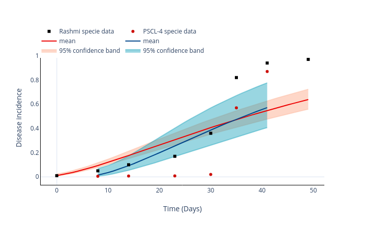

Inference results using NUTs for TLCVD no resisitence tomato specie data. Fit the deterministic model to the data.

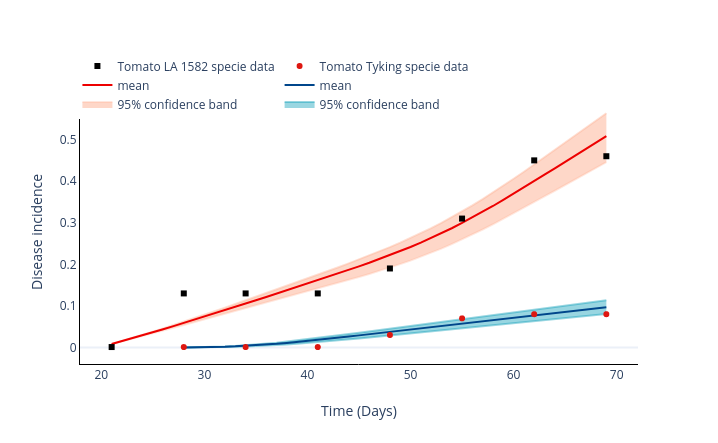

Inference results using NUTs for TLCVD resisitence tomato specie data. Fit the deterministic model to the data.

For this adjustments we use all data bases of Holt et al. [@Holt1999]. We observe that almost all no resistance specie data are outside the confidence band, but the fitted curve is closer to the first data than to the last data, due to the abrupt growth in the number of infected cases that occur. On the other hand, the adjustment made with the data of resistant species can be observed that after $40$ days, the confidentiality band conforms to most of the data, unlike the confidentiality bands of the data of nonresistant species. The results showed that the curves adjusted with the SLI-SI model for each of the tomato species behaves similarly to the data.

# Stan model for tomato LA 1582 specie data

```r
library(rstan)
```

```r
writeLines(readLines("sirTomato2.stan"))
```

```
## functions {
##   real[] SIR(real t,  // time
##              real[] y,
##              real[] theta,
##              real[] x_r,
##              int[] x_i) {
##
##     real dy_dt[7];
##     real Sp = y[1];
##     real Lp = y[2];
##     real Ip = y[3];
##     real Sv = y[4];
##     real Iv = y[5];
##     real Dv = y[6];
##     real Yp = y[7];
## //
##     real beta_p = theta[1];
##     real r_1 = theta[2];
##     real r_2 = theta[3];
##     real b = theta[4];
##     real beta_v = theta[5];
##     real gamma = theta[6];
##     real gamma_f = theta[7];
##     real theta_1 = theta[8];
##     real mu = theta[9];
##     real Np = Sp + Lp + Ip;
##     real Nv = Sv + Iv;
##
##     dy_dt[1] = -beta_p * Sp * Iv/ Nv + r_1 * Lp + r_2 * Ip;
##     dy_dt[2] = beta_p * Sp * Iv /Nv - (b + r_1) * Lp;
##     dy_dt[3] = b * Lp - r_2 * Ip;
##     dy_dt[4] = -beta_v * Sv * Ip / Np - (gamma + gamma_f) * Sv + (1 - theta_1) * mu;
##     dy_dt[5] = beta_v * Sv * Ip / Np - (gamma + gamma_f) * Iv + theta_1 * mu;
##     dy_dt[6] = (gamma + gamma_f) * (Sv + Iv) - mu;
##     dy_dt[7] = b * Lp;
##     return dy_dt;
##   }
##
## }
## data {
```

[output cut: 111 more lines]

```
##
##     y[1:(n_obs-1)] ~ neg_binomial_2(lambda,phi);
##
## }
##
## generated quantities {
##     real R_0;      // Basic reproduction number
##     real pred_cases[n_obs];
##     real lambda[n_obs];
##     R_0 = (beta_p * beta_v * b /((b + r_1) * (gamma + gamma_f)* r_2))^(1/2);
##     for (i in 1:n_obs){
##       lambda[i] = y_hat[i,3];
##     }
##
## }
```

# Stan model for tomato tyking specie data

```r
library(rstan)
writeLines(readLines("sirTomato3.stan"))
```

```
## functions {
##   real[] SIR(real t,  // time
##              real[] y,
##              real[] theta,
##              real[] x_r,
##              int[] x_i) {
##
##     real dy_dt[7];
##     real Sp = y[1];
##     real Lp = y[2];
##     real Ip = y[3];
##     real Sv = y[4];
##     real Iv = y[5];
##     real Dv = y[6];
##     real Yp = y[7];
## //
##     real beta_p = theta[1];
##     real r_1 = theta[2];
##     real r_2 = theta[3];
##     real b = theta[4];
##     real beta_v = theta[5];
##     real gamma = theta[6];
##     real gamma_f = theta[7];
##     real theta_1 = theta[8];
##     real mu = theta[9];
##     real Np = Sp + Lp + Ip;
##     real Nv = Sv + Iv;
##
##     dy_dt[1] = -beta_p * Sp * Iv/ Nv + r_1 * Lp + r_2 * Ip;
##     dy_dt[2] = beta_p * Sp * Iv /Nv - (b + r_1) * Lp;
##     dy_dt[3] = b * Lp - r_2 * Ip;
##     dy_dt[4] = -beta_v * Sv * Ip / Np - (gamma + gamma_f) * Sv + (1 - theta_1) * mu;
##     dy_dt[5] = beta_v * Sv * Ip / Np - (gamma + gamma_f) * Iv + theta_1 * mu;
##     dy_dt[6] = (gamma + gamma_f) * (Sv + Iv) - mu;
##     dy_dt[7] = b * Lp;
##     return dy_dt;
##   }
##
## }
## data {
```

[output cut: 107 more lines]

```
##     phi_inv ~ exponential(1.9);
##        //likelihood
##      for (i in 1:n_obs-1){
##       lambda[i] = y_hat[i,7];
##     }
##     y[1:(n_obs-1)] ~ neg_binomial_2(lambda,phi);
##
## }
##
## generated quantities {
##     real R_0;      // Basic reproduction number
##
##     R_0 = (beta_p * beta_v * b /((b + r_1) * (gamma + gamma_f)* r_2))^(0.5);
##
## }
```

##References